# Bio 204: Problem Set 03

# Due Date: 07 October 2016

# The `trees` data set

The built-in `trees` data set consists of measurements of the girth, height, and volume of 31 black cherry trees. Read the documentation for `trees` before proceeding to answer the questions below.

# Problem 1

## Problem 1.1: Summary stats (2 pts)

Using the `dplyr` functions `summarize_all` and `funs`, generate a summary table giving the mean and standard deviation, for each of the variables in `trees`. Your output should look like this:

```
  Girth_mean Height_mean Volume_mean Girth_sd Height_sd Volume_sd
1   13.24839          76    30.17097 3.138139  6.371813  16.43785
```

```r
# Problem 1.1 code
```

## Problem 1.2: Univariate distributions (2 pts)

Using the `ggplot2` and `cowplot` libraries, generate histograms for each of the variables in `trees`, formatted as shown below:

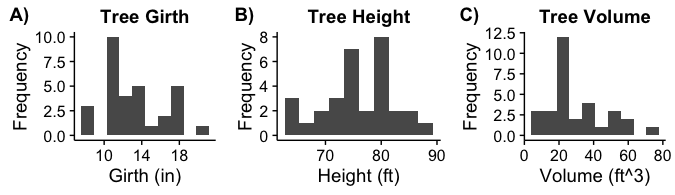

Expected output for problem 1.2

```r
# Problem 1.2 code
```

## Problem 1.3: Measures of association (1 pt)

Calculate a correlation matrix for the variables in `trees`. Your output should look like this:

```
           Girth    Height    Volume
Girth  1.0000000 0.5192801 0.9671194
Height 0.5192801 1.0000000 0.5982497
Volume 0.9671194 0.5982497 1.0000000
```

```r
# Problem 1.3 code
```

# Problem 1.4: Pairs plot (1 pt)

Using the `GGally` package, generate a “pairs plot” depicting the pairwise relationships in the data, like the one below.

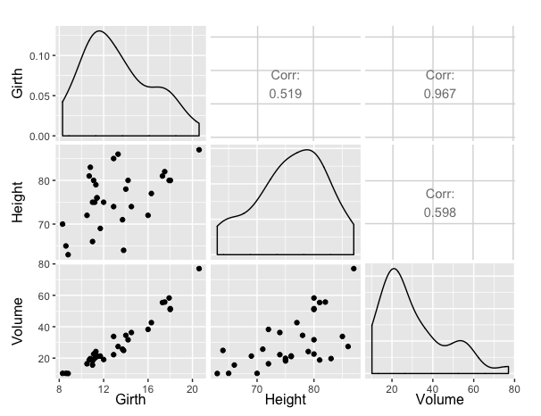

Expected output for problem 1.4

```r
# Problem 1.4 code
```

# Problem 2

Let’s imagine we’re lumberjacks, but our permit only allows us to harvest a fixed number of trees. We get paid by the total volume of wood we harvest, so we’re interested in predicting a tree’s volume (hard to measure directly) as a function of its girth and height (relatively easy to measure), so we can pick the best trees to harvest.

## Problem 2.1a (2 pts)

Generate a linear regression model you could use to predict Volume as a function of Girth. What is the equation for the linear model estimated by the regression?

```r
# Problem 2.1a code
```

## Problem 2.1b (2 pts)

Generate a regression plot for Volume as a function of Girth.

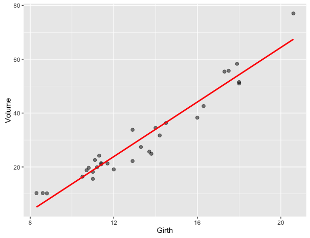

Expected output for problem 2.1b

```r
# Problem 2.1b code
```

## Problem 2.2a (2 pts)

Generate a linear regression model you could use to predict Volume as a function of Grith **and** Height. What is the equation for the linear model estimated by the regression?

```r
# Problem 2.2a code
```

## Problem 2.2b (2 pts)

Using the `plot3D` package, a scatter plot depicting all three variables as shown below.

[figure not shown]

Expected output for problem 2.2b

```r
# Problem 2.2b code
```

## Problem 2.3c (2pts)

An alternate way you might depict this 3D data set is using a bivariate scatter plot, where the third variable (Volume) is depicted using the size of the points. Use `ggplot` to generate the figure below.

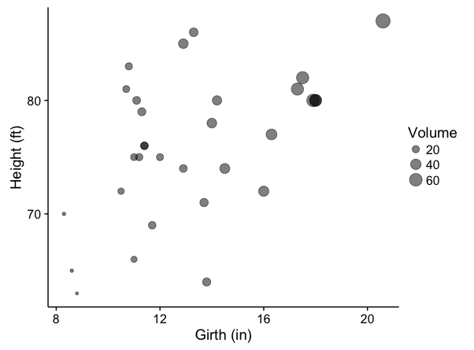

Expected output for problem 2.3c

```r
# Problem 2.3c code
```

# Problem 3

Let’s think about the relationships we’re actually modeling for a few minutes. For the sake of simplicity let’s consider the trunk of a tree to be a cylinder. How do the dimensions of this cylinder relate to its volume? You can look up the formula for the volume of a cylinder, but the key thing you’ll want to note is that volume of the cylinder should be proportional to a characteristic length of the cylinder cubed ($V \propto L^3$). This suggests that if we want to fit a linear model we should relate Girth to $\sqrt[3]{\mbox{Volume}}$.

## Problem 3a (2 pts)

Using the `dplyr` function `mutate`, add a derived variable for the cube root of volume, $\sqrt[3]{\mbox{Volume}}$ to the `trees` data frame.

```r
# Problem 3a code
```

## Problem 3b (2 pts)

Fit a regression model to predict $\sqrt[3]{\mbox{Volume}}$ from Girth. What is the equation for the linear model estimated by this regression?

```r
# Problem 3b code
```

## Extra credit: Problem 3c (2 pts)

Using the `ggplot` and `cowplot` libraries, generate side by side *residual plots* showing: a) Volume as a function of Girth and b) $\sqrt[3]{\mbox{Volume}}$ as a function of Girth.

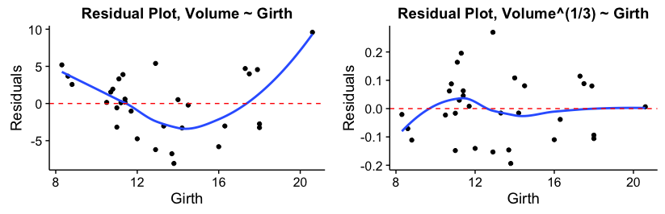

Expected output for problem 3c

```r
# Problem 3c code
```

## Extra credit: Problem 3d (2 pts)

Interpret the residual plots you generated in Problem 3c, in terms of what they tell you about model fit.